# Preprocesamiento

- Análisis exploratorio, gráficos, etc
- Tratamiento de variables

# AgeOutcome

Ver este estupendo script en kaggle, donde viene hecho la mayoría de tratamiento de variables que he realizado. https://www.kaggle.com/mrisdal/shelter-animal-outcomes/quick-dirty-randomforest

- La variable AgeOutcome viene en formato chungo

```
##  [1] "0 years"   "10 months" "10 years"  "11 months" "11 years"
##  [6] "12 years"  "13 years"  "14 years"  "15 years"  "16 years"
## [11] "17 years"  "18 years"  "19 years"  "1 day"     "1 month"
## [16] "1 week"    "1 weeks"   "1 year"    "20 years"  "22 years"
## [21] "2 days"    "2 months"  "2 weeks"   "2 years"   "3 days"
## [26] "3 months"  "3 weeks"   "3 years"   "4 days"    "4 months"
## [31] "4 weeks"   "4 years"   "5 days"    "5 months"  "5 weeks"
## [36] "5 years"   "6 days"    "6 months"  "6 years"   "7 months"
## [41] "7 years"   "8 months"  "8 years"   "9 months"  "9 years"
```

La convertimos a días

# Conversión a días de AgeuponOutcome

```r
# He unido los conjuntos de train y test
# Extraemos el número

unido$TimeValue <- sapply(unido$AgeuponOutcome,
                         function(x) strsplit(x, split = ' ')[[1]][1])

# extraemos si es año, mes o día :
unido$UnitofTime <- sapply(unido$AgeuponOutcome,
                          function(x) strsplit(x, split = ' ')[[1]][2])

head(unido$UnitofTime)
```

```
## [1] "year"  "year"  "years" "weeks" "years" "month"
```

```r
# Quitamos las 's'
unido$UnitofTime <- gsub('s', '', unido$UnitofTime)

unido$TimeValue  <- as.numeric(unido$TimeValue)
unido$UnitofTime <- as.factor(unido$UnitofTime)

#
multiplier <- ifelse(unido$UnitofTime == 'day', 1,
                     ifelse(unido$UnitofTime == 'week', 7,
                            ifelse(unido$UnitofTime == 'month', 30,
                                   ifelse(unido$UnitofTime == 'year', 365, NA))))

# Aplicamos
unido$AgeinDays <- unido$TimeValue * multiplier

# a los casos perdidos les imputo la media
unido$AgeinDays[is.na(unido$AgeinDays)] <- median(unido$AgeinDays, na.rm=TRUE)
summary(unido$AgeinDays)
```

```
##    Min. 1st Qu.  Median    Mean 3rd Qu.    Max.
##     0.0    60.0   365.0   788.3  1095.0  8030.0
```

# Relación Age in Days con la variable respuesta

Básicamente, los animales que se adoptan, transfieren o mueren, son en media, más jóvenes que los que se devuelven a los propietarios o que se les practica la eutanasia.

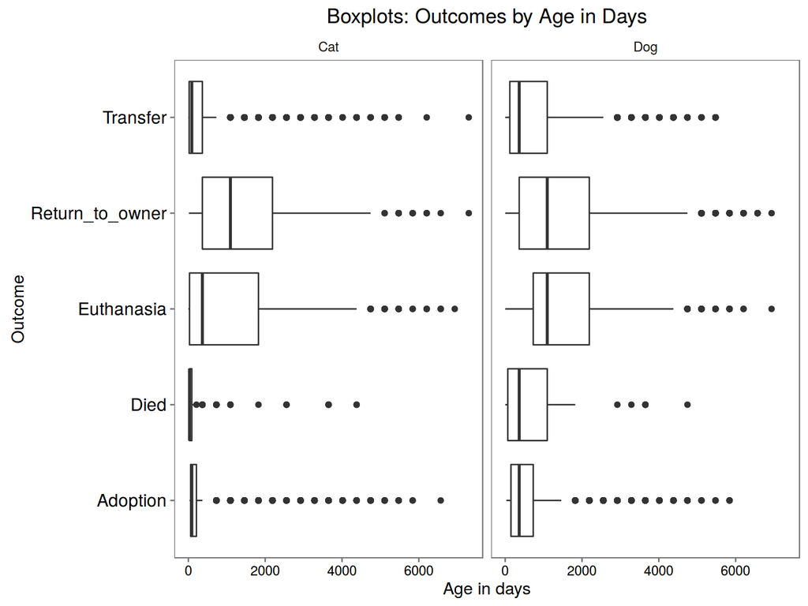

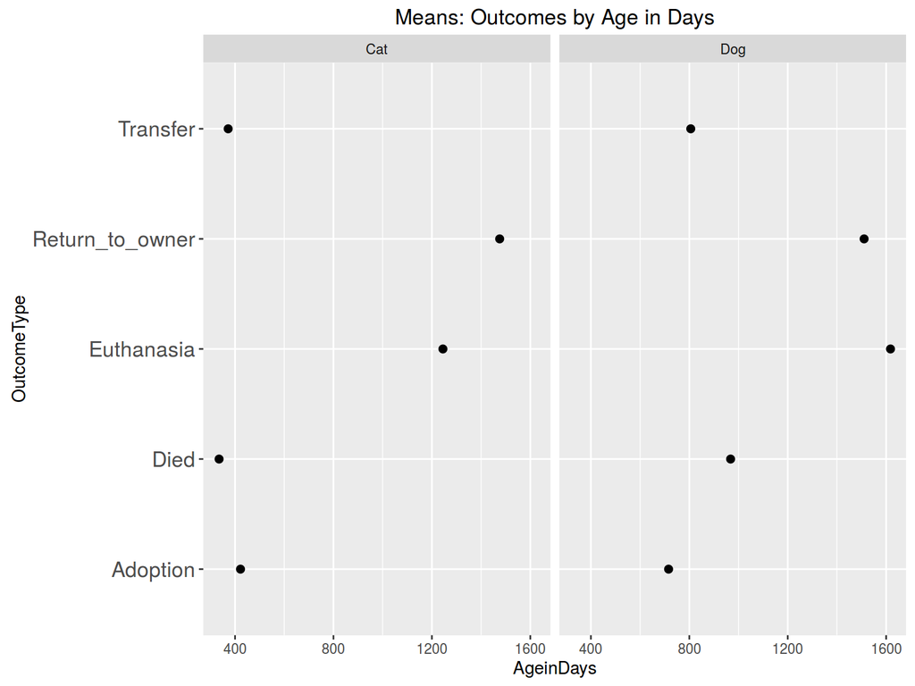

# Animales sin nombre

Creamos variable que identifique si un animal tiene nombre o no. (1:animales con nombre)

Vemos la tabla de %

```
## [1] 10916
```

```
##                  conNombre
## OutcomeType               0         1
##   Adoption        15.581762 84.418238
##   Died            60.913706 39.086294
##   Euthanasia      52.411576 47.588424
##   Return_to_owner  3.196824 96.803176
##   Transfer        52.271280 47.728720
```

# Breed

Hay 1678 razas. Creamos una variable que contenga las más comunes y el resto las agrupe bajo la categoría de “otros”

```r
# vamos a quedarnos con las más populares
# con summary(as.factor(unido$Breed),maxsum=30L) vemos las 30 más numerosas
summary(as.factor(unido$Breed),maxsum=30L)
```

```
##        Domestic Shorthair Mix                  Pit Bull Mix
##                         12587                          2776
##       Chihuahua Shorthair Mix        Labrador Retriever Mix
##                          2498                          1949
##      Domestic Medium Hair Mix           German Shepherd Mix
##                          1217                           830
##         Domestic Longhair Mix                   Siamese Mix
##                           753                           562
##     Australian Cattle Dog Mix                 Dachshund Mix
##                           513                           437
##          Miniature Poodle Mix                     Boxer Mix
##                           336                           330
##             Border Collie Mix       Australian Shepherd Mix
##                           324                           256
##               Rat Terrier Mix                 Catahoula Mix
##                           226                           216
##         Yorkshire Terrier Mix      Jack Russell Terrier Mix
##                           213                           203
##       Miniature Schnauzer Mix            Domestic Shorthair
##                           203                           194
##            Siberian Husky Mix        Chihuahua Longhair Mix
##                           187                           186
##                    Beagle Mix                Rottweiler Mix
##                           172                           162
##          American Bulldog Mix                  Shih Tzu Mix
##                           161                           152
## Chihuahua Shorthair/Dachshund             Cairn Terrier Mix
##                           151                           150
##         Australian Kelpie Mix                       (Other)
##                           138                         10103
```

# Breed

Una forma de ver la relación entre las razas más populares y Outcome es mediante un simple análisis de correspondencias. Separamos por tipo de animal

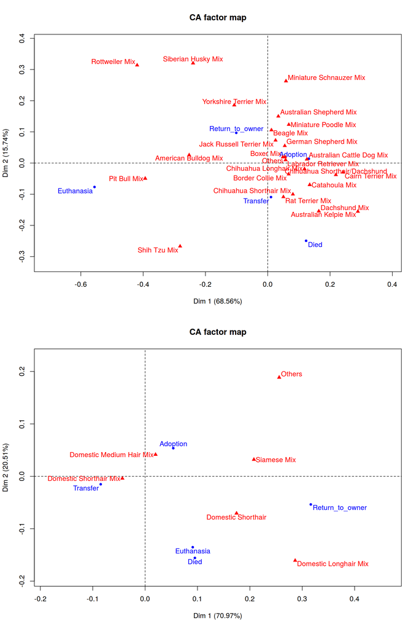

# SexuponOutcome

En esta variable está la información de si es macho o hembra y de si está castrado o no. Separamos esa información

```r
unido$Intact[grepl('Intact',unido$SexuponOutcome)] <- "Intacto"
unido$Intact[grepl('Unknow',unido$SexuponOutcome)] <- "No se sabe"

unido$Intact[is.na(unido$Intact) & ! is.na(unido$SexuponOutcome)] <- "Esterilizado"
unido$Intact[is.na(unido$Intact)  ] <- "No se sabe"

unido$Sex[grepl('Male', unido$SexuponOutcome)] <- "Male"
unido$Sex[grepl('Female', unido$SexuponOutcome)] <- "Female"
unido$Sex[grepl('Unknown', unido$SexuponOutcome)] <- "Unknown"

unido$Sex[is.na(unido$Sex)] <- "Unknown"
```

# SexuponOutcome

Vemos la tabla en relación a la variable OutcomeType. En % en cada categoría de OutcomeType

```
##                  Sex
## OutcomeType           Female       Male    Unknown
##   Adoption        50.0417866 49.9582134  0.0000000
##   Died            37.5634518 49.7461929 12.6903553
##   Euthanasia      40.7073955 52.7974277  6.4951768
##   Return_to_owner 42.8123694 56.9160050  0.2716256
##   Transfer        44.4279346 45.4362131 10.1358523
```

```
##                  Intact
## OutcomeType       Esterilizado    Intacto No se sabe
##   Adoption          96.6477853  3.3522147  0.0000000
##   Died              18.7817259 68.5279188 12.6903553
##   Euthanasia        37.0418006 56.4630225  6.4951768
##   Return_to_owner   83.4726285 16.2557459  0.2716256
##   Transfer          38.0280195 51.8361282 10.1358523
```

Es claro que si influye. Entre los animales que son adoptados el 96% están esterilizados. Si vemos la tabla en forma de un análisis de correspondencias, se ve más claramente esta relación, estar esterilizado discrimina claramente entre que el animal sea adoptado o devuelto al propietario frente al resto de categorías.

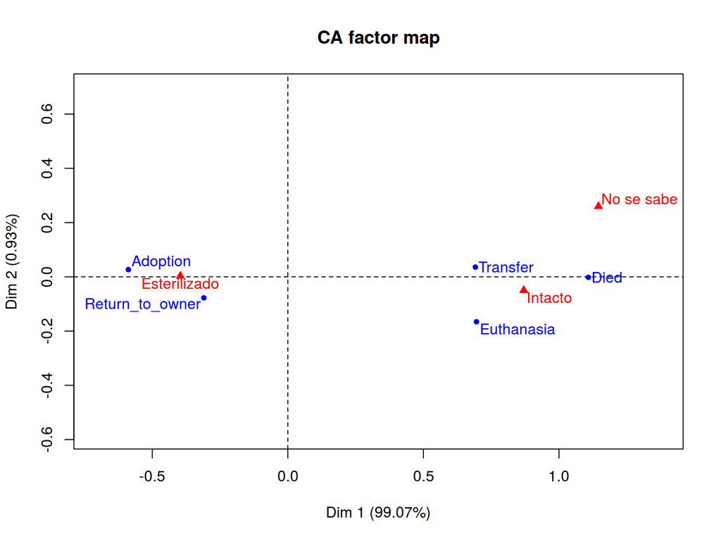

# Otras transformaciones

- Convertir a numérica la variable DateTime. `as.numeric(as.POSIXct(unido$DateTime))`
- Extraer año, mes, dia mes, dia de la semana y hora de la variable DateTime
- Crear nueva variable categorizando la variable AgeinDays en cachorro (<365 ), joven (>365 & <365*2) y adulto
- Quedarnos sólo con el primer color del animal.

# Modelos

Dos estrategias

- Modelo de tree boosting.
- Stacking de diferentes modelos

# Gradient boosting machine

En problemas de clasificación es lo que está funcionando mejor.

- Una librería muy buena es xgboost https://github.com/dmlc/xgboost
- Está implementada para R, python, scala, java, c++ y también se puede instalar en Hadoop, Spark, Flink y DataFlow
- Sigue la filosofía **unix** de hacer solo una cosa pero muy bien.

# Tuning del modelo

En el modelo de tree boosting con xgboost hay que ajustar varios parámetros. Entre otros, los siguientes

- max_depth: Profundidad máxima
- Subsample: % de datos muestreados para evitar overfitting
- colsample_bytree: % de columnas muestreadas para cada árbol
- nrounds: número de iteraciones del boosting

# Tuning del modelo

- Búsqueda greedy de mejor modelo con diferentes combinaciones de max_depth, subsample y colsample_bytree
- En cada modelo se elige el número de iteraciones que minimiza el multilogloss mediante validación cruzada. (mismos folds en todos los modelos)
- Ajuste de alrededor de 100 modelos para encontrar una buena combinación de parámetros.
- Se hacen varios submits a kaggle para comprobar el multilogloss en el conjunto de test

# Mlogloss en CV según profundidad árbol

```
##    Modelo max_depth colsample_bytree subsample mlogloss
## 22     23        11              0.9       0.6 0.730814
## 28     22        10              0.9       0.6 0.731173
## 44     31        11                1       0.6 0.733398
## 59     34         6              0.5       0.8 0.735588
## 74     87        11              0.9         1 0.739710
## 76      1         5              0.5       0.6 0.740965
## 84     25         5                1       0.6 0.742272
## 85     65         5              0.5         1 0.742764
## 86     93         9                1         1 0.743041
## 89     82         6              0.9         1 0.743696
```

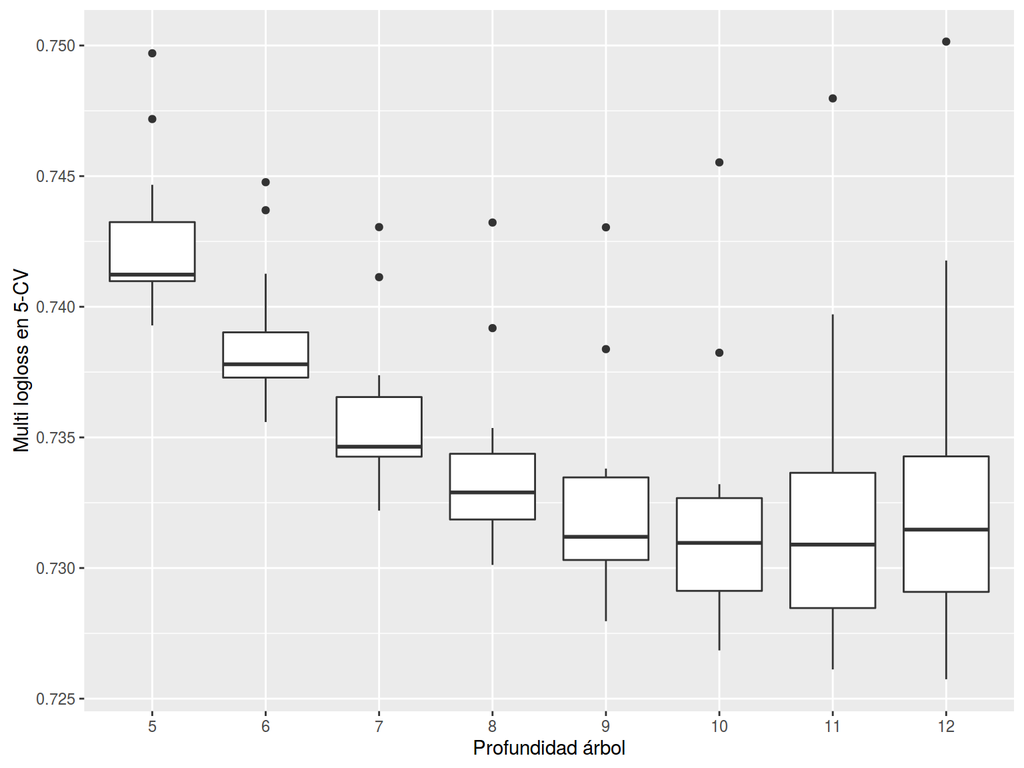

# Mlogloss según profundidad y subsample

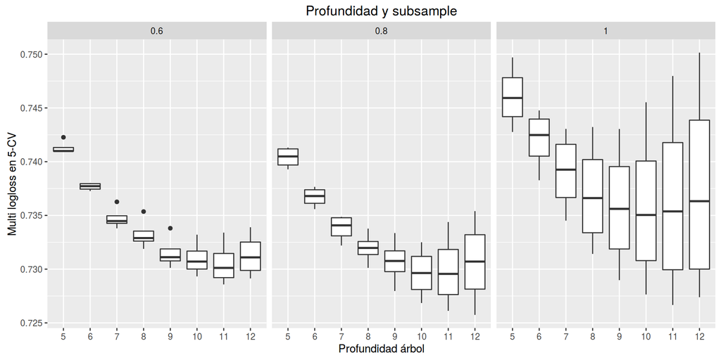

# Mlogloss según profundidad y colsample_bytree

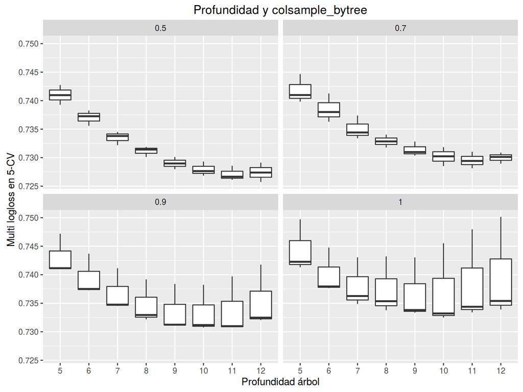

# Variables importantes en el modelo final

En el modelo final, obtuve un mlogloss de 0.725 en validación cruzada y 0.706 en kaggle (puesto 8)

Las variables más importantes según el modelo fueron

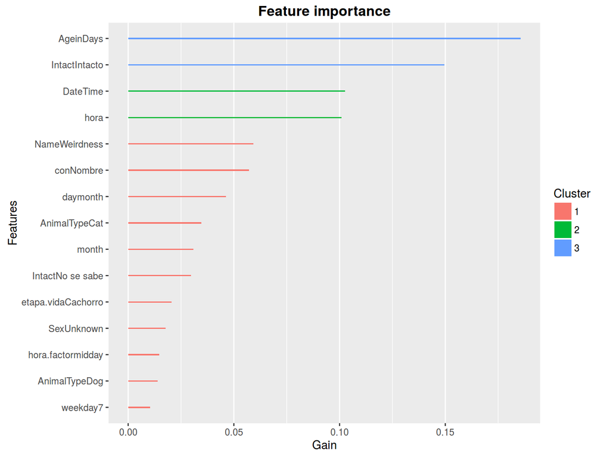

# Stacking de diferentes modelos

- Se trata de ajustar diferentes modelos y luego entrenar un metamodelo
- Partir la muestra de entrenamiento en 7 folds. Reservar uno para entrenar el metamodelo
- En los otros 6 folds ajustar diferentes modelos con validación cruzada y obtener una estimación creíble del multi logloss. Cada modelo se ajusta al final utilizando los 6 folds.
- Dar predicciones de cada modelo para el fold restante y para el conjunto de test.
- Entrenar un meta modelo en el *fold* restante utilizando como variables las predicciones de los modelos anteriores.
- Obtener predicciones para el conjunto de test

# Modelos considerados

- Naive Bayes
- k-vecinos. k=5
- RandomForest
- Multinomial clásico
- Multinomial con penalización lasso. glmnet
- Mixture discriminan analysis
- Flexible discriminant analysis
- svm
- J4.8 usando Rweka
- Logistic model tree. Rweka
- logit boost. Rweka
- xgboost
- h2o.deeplearning

# Mlogloss

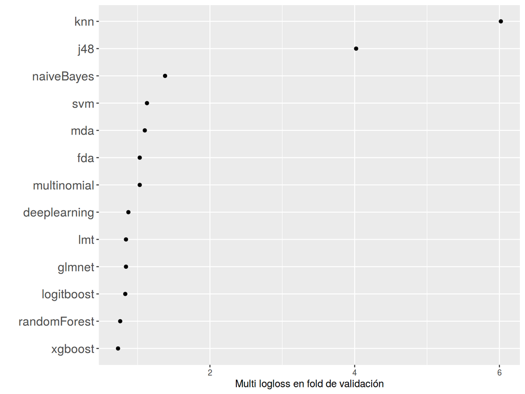

# Mlogloss

Quitando knn y j48

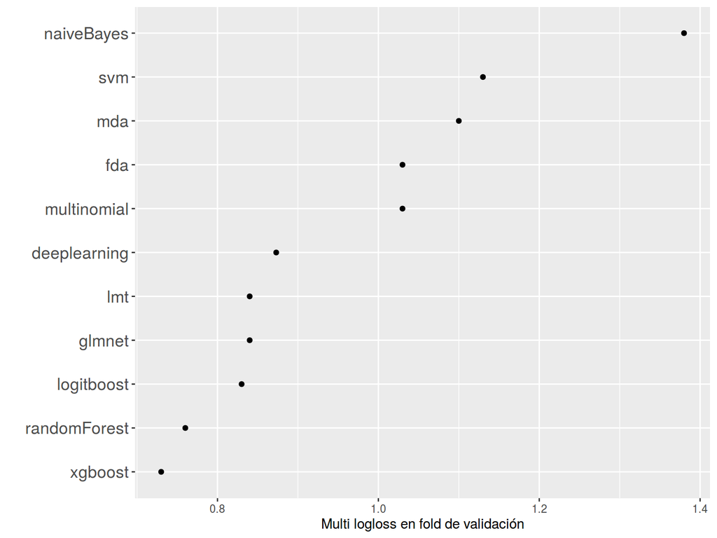

# Ajuste del metamodelo

- Pendiente todavía

# Temas pendientes

- Problema clases desbalanceadas. SMOTE
- Reducir variables, crear nuevas, combinaciones.